# W3 Assignment (Assignment 2) - BDA 503

Selçuk Açıkalın

04 Kas 2020

# A Short Review of EPIAS September’20 Electricty Market Prices

### A Glance at the Data

Dataframe consists of hourly realized electricity prices, imbalance prices and SMP Direction values - MCP : Market Clearing Price - SMP : System Marginal Price

```
## Rows: 720
## Columns: 6
## $ Date                                <chr> "01.09.20 00:00", "01.09.20 01:...
## $ MCP                                 <dbl> 302.39, 300.25, 292.64, 290.00,...
## $ SMP                                 <dbl> 332.39, 325.25, 317.64, 320.00,...
## $ `Positive Imbalance Price (TL/MWh)` <dbl> 293.32, 291.24, 283.86, 281.30,...
## $ `Negative Imbalance Price (TL/MWh)` <dbl> 342.36, 335.01, 327.17, 329.60,...
## $ `SMP Direction`                     <chr> "? Energy Deficit", "? Energy D...
```

For other details of how the market works link is provided: [Mini Tutorial about Electricity Market Prices](https://pjournal.github.io/files/electricity_markets_mini_tutorial)

### Summary of Hourly MCP and SMP Over 720 hours of Sep’20

[output not shown]

Average hourly MCP and average hourly SMP is seemed not to met with each other most of the time. This gives a clue about most of the days and hours in September’20 electricity markets closed with an imbalanced price.

### Daily Average and Median Values of MCP and SMP

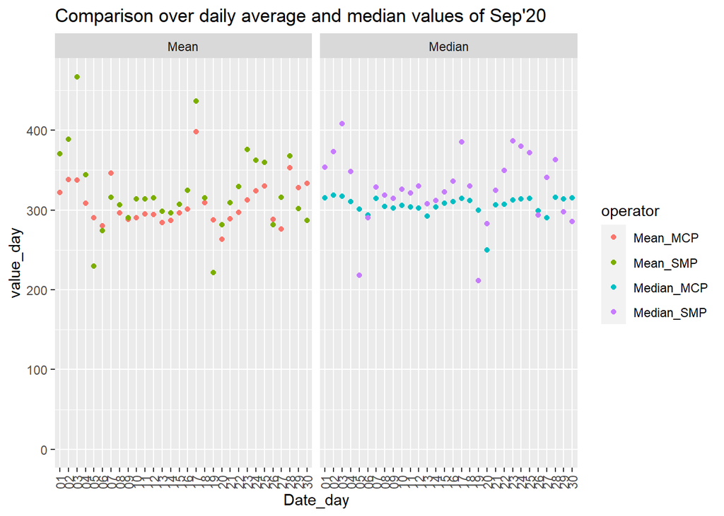

It is easier to tell which day is mostly ended with energy surplus or energy deficit by looking at daily averages or medians. Looking at the graphs:

- On 3rd, 5th, 17th and 19th of Sep’20 you may see obvious extreme SMP values caused deficit or surplus.
- Median of MCP values could lead the interpretation of general daily demand forecast is centered between 300 and 325.
- Between 20th and 27th of Sep’20 a slight increase in the demand for electricity is seemed to be happened with a negative imbalance.

### Daily Min and Max Values of MCP and SMP

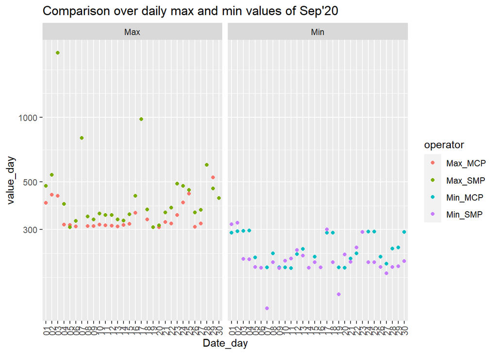

When we look at the min and max graphs:

- On 3rd, 7th and 17th of Sep’20 instant peaks in electricty demands are observed since SMP realization is way too high.
- Contrarily on 7th and 19th of Sep’20 the two lowest hourly SMP realization is seen over the series.
- These extreme values could lead interpretations such as on these hours extraneous events may occured that maximizes or minimizes the energy consumption or causes problems on the energy production side.